# How to Beat The Thai Market With Value Investing

Charin Polpanumas

February 18, 2559 BE

# 1 Executive Summary

We set out to find whether value investing strategy such as Joel Greenblatt’s earning yields and Piotroski’s F-score can actually beat the Thai stock market. The fundamental data are obtained from [Morningstar](http://www.morningstar.com) while the benchmark SET TRI is obtained from [Stock Exchange of Thailand](http://set.or.th). We perform support vector machine, boosted logistic regression, random forest classification and neural networks based on the data, as well as a backtest to verify the models. Most our models perform better than a coin toss with random forest achieving the highest accuracy and precision of 85.13% and 87.59% respectively (58.05% annual return). The average annual SET TRI return is 21.19%.

Visit our github respository [here](https://github.com/cstorm125/value/)

# 2 Data Processing

Attach necessary R packages and set seed for reproduciblity.

```r
#plotting
library(ggplot2)
library(gridExtra)
#For caret package
library(lattice)
library(caret)
#For svm
library(e1071)
#For gbm
library(gbm)
library(survival)
library(splines)
library(parallel)
library(plyr)
#For rf
library(randomForest)
#For nnet
library(neuralnet)
#Set seed for reproducibility
set.seed(385)
```

Read and subset the data containing `valuation ratios`, `valuation and quality indicators`, `common size ratios`, and `per share data`. These variables are the go-to components of various value investing strategies such as Joel Greenblatt’s Magic Numbers, Peter Lynch’s fair value, Piotroski F-score, and other fundamental criteria. For more information on variables included, see the codebook. We only get those with complete cases due to requirement of the analysis.

```r
#Read dataset
udf<-read.csv('udf.csv')

#Subset data for analysis
dat<-udf[,c(2,3,116:152,155:184,187:189)]

#Get only with complete cases
dat<-dat[complete.cases(dat),]
```

The price growth variable `priceg` is skewed to the right; that is, we tend to have extreme positive price growth as large as 2,733%. Since events outside the scope of value investing strategies, such as transitioning from one industry to another, merger and acquisition or even share splitting mistakes, might cause these extreme values, we decide to remove outliers beyond median plus/minus three standard deviations (12 observations were removed).

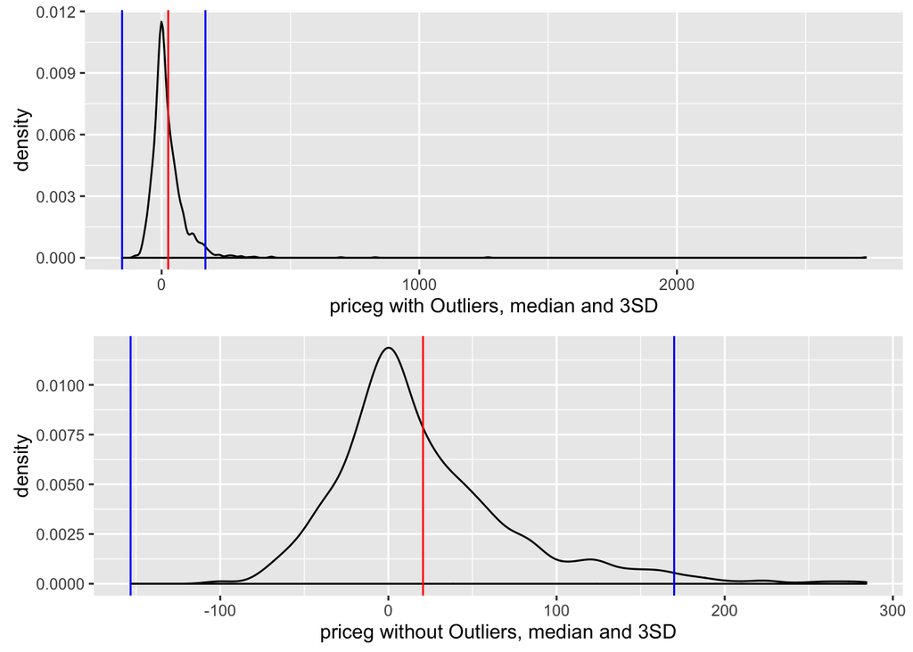

```r
#Central values with outliers
med<-median(dat$priceg)
upper <-med+sd(dat$priceg)*3
lower <-med-sd(dat$priceg)*3

#Plot with outliers
g<-ggplot(dat,aes(x=priceg))+geom_density()+xlab('priceg with Outliers, median and 3SD')
g<-g+geom_vline(aes(xintercept=mean(priceg, na.rm=T)),color="red") #add median
g<-g+geom_vline(aes(xintercept=upper),color="blue") #add upper
g<-g+geom_vline(aes(xintercept=lower),color="blue") #add upper

#Remove outliers
dat<-dat[dat$priceg>lower&dat$priceg<upper,]
#Central values without outliers
med<-median(dat$priceg)
upper <-med+sd(dat$priceg)*3
lower <-med-sd(dat$priceg)*3

#Plot without outliers
h<-ggplot(dat,aes(x=priceg))+geom_density()+xlab('priceg without Outliers, median and 3SD')
h<-h+geom_vline(aes(xintercept=mean(priceg, na.rm=T)),color="red") #add median
h<-h+geom_vline(aes(xintercept=upper),color="blue") #add upper
h<-h+geom_vline(aes(xintercept=lower),color="blue") #add upper

#Plot both
grid.arrange(g,h,ncol=1)
```

We create the `winloss` variable as a binary dependent variable of if the stock *win* or *lose* against the market.

```r
#Create winloss variable as dependent
dat$winloss <- ifelse(dat$priceg-dat$set_return>0,'win','lose')
```

This result in a dataset of 73 variables and 1,580 observations.

# 3 Exploratory Data Analysis

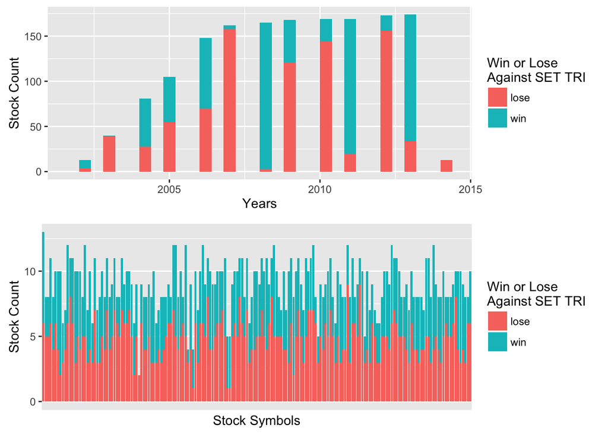

```r
#Year spread
g<-ggplot(dat, aes(x=i,fill=winloss))+geom_histogram()
g<-g+xlab('Years')+ylab('Stock Count')+scale_fill_discrete(name="Win or Lose\nAgainst SET TRI")

#Symbol spread
h<-ggplot(dat, aes(x=symbol,fill=winloss))+stat_count()
h<-h+xlab('Stock Symbols')+ylab('Stock Count')+scale_fill_discrete(name="Win or Lose\nAgainst SET TRI")
h<-h+scale_x_discrete(breaks=NULL) #hide x ticks
#Plot both
grid.arrange(g,h,ncol=1)
```

# 4 Modeling

We prepare randomly training and testing sets at 60/40 ratio. This results in 948 observations in `training` set and 632 observations in `testing` set. We also removed variables associated with year indicator, symbols, SET TRI return and price growth since it interferes with the training. The models used are support vector machine, boosted logistic regression, random forest and neural networks. Also leave `backtest` data frame for backtesting.

```r
#Leave a dataset for backtesting
backtest<-dat

#Remove all unnecessary variables for training
dat<-subset(dat,select=-c(i,symbol,set_return,priceg))

#Create training and testing sets
inTrain <- createDataPartition(dat$winloss,p=0.6,list=FALSE)
training<-dat[inTrain,]
testing<-dat[-inTrain,]
backtest<-backtest[-inTrain,]
```

## 4.1 Support Vector Machine

We use c-classification support vector machine with linear kernel and gamma of 1/68.

```r
fit<-svm(winloss~.,data=training, type='C',kernel='linear')
```

Testing reveals out-of-sample 64.72% accuracy. We also get 64.14% out-of-sample precision, meaning 64.14% of stocks we labelled as market beaters are actually so.

```r
pred<-predict(fit,newdata=testing)
confusionMatrix(pred,testing$winloss,positive = 'win')
```

```
## Confusion Matrix and Statistics
##
##           Reference
## Prediction lose win
##       lose  248 133
##       win    90 161
##
##                Accuracy : 0.6472
##                  95% CI : (0.6085, 0.6844)
##     No Information Rate : 0.5348
##     P-Value [Acc > NIR] : 6.937e-09
##
##                   Kappa : 0.2841
##  Mcnemar's Test P-Value : 0.004915
##
##             Sensitivity : 0.5476
##             Specificity : 0.7337
##          Pos Pred Value : 0.6414
##          Neg Pred Value : 0.6509
##              Prevalence : 0.4652
##          Detection Rate : 0.2547
##    Detection Prevalence : 0.3972
##       Balanced Accuracy : 0.6407
##
##        'Positive' Class : win
##
```

Following this classifier will give an average return (%) of:

```r
mean(backtest[backtest$winloss==pred & pred=='win',]$priceg)
```

```
## [1] 65.59239
```

## 4.2 Boosted Logistic Regression

The boosted logit with 150 iterations and step-size reduction of 0.1 with 25 repetitions of bootstrap cross-validation.

```r
fit<-train(winloss~.,data=training, method='gbm')
```

64 out of 68 features have an influence on the dependent variable. The variable importance of top-ten most influential variables are shown below.

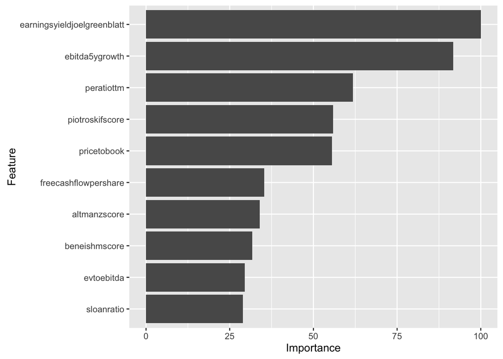

```r
ggplot(varImp(fit),top=10)
```

This gives a slightly inferior out-of-sample accuracy of 63.13% and a little better precision of 65.64% respectively.

```r
pred<-predict(fit,newdata=testing)
confusionMatrix(pred,testing$winloss,positive = 'win')
```

```
## Confusion Matrix and Statistics
##
##           Reference
## Prediction lose win
##       lose  271 166
##       win    67 128
##
##                Accuracy : 0.6313
##                  95% CI : (0.5924, 0.669)
##     No Information Rate : 0.5348
##     P-Value [Acc > NIR] : 5.855e-07
##
##                   Kappa : 0.2425
##  Mcnemar's Test P-Value : 1.361e-10
##
##             Sensitivity : 0.4354
##             Specificity : 0.8018
##          Pos Pred Value : 0.6564
##          Neg Pred Value : 0.6201
##              Prevalence : 0.4652
##          Detection Rate : 0.2025
##    Detection Prevalence : 0.3085
##       Balanced Accuracy : 0.6186
##
##        'Positive' Class : win
##
```

Following this classifier will give an average return (%) of:

```r
mean(backtest[backtest$winloss==pred & pred=='win',]$priceg)
```

```
## [1] 65.73453
```

## 4.3 Random Forest Classification

We grow 500 classification trees with 25 repetitions of bootstrap cross-validation. The cutoff for voting is 50%.

```r
fit<-train(winloss~.,data=training, method='rf')
```

The variable importance of top-ten most influential variables are shown below.

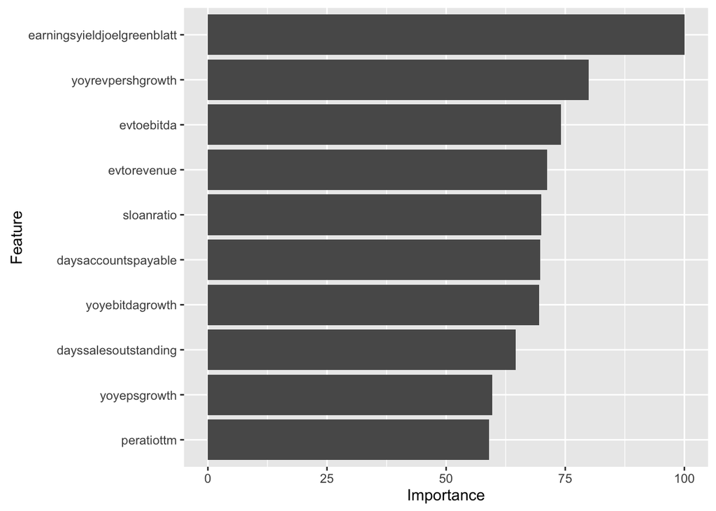

```r
ggplot(varImp(fit),top=10)
```

This gives the best result so far with 85.13% accuracy and 87.59% precision.

```r
pred<-predict(fit,newdata=testing)
confusionMatrix(pred,testing$winloss,positive = 'win')
```

```
## Confusion Matrix and Statistics
##
##           Reference
## Prediction lose win
##       lose  305  61
##       win    33 233
##
##                Accuracy : 0.8513
##                  95% CI : (0.8211, 0.8781)
##     No Information Rate : 0.5348
##     P-Value [Acc > NIR] : < 2.2e-16
##
##                   Kappa : 0.6992
##  Mcnemar's Test P-Value : 0.005355
##
##             Sensitivity : 0.7925
##             Specificity : 0.9024
##          Pos Pred Value : 0.8759
##          Neg Pred Value : 0.8333
##              Prevalence : 0.4652
##          Detection Rate : 0.3687
##    Detection Prevalence : 0.4209
##       Balanced Accuracy : 0.8474
##
##        'Positive' Class : win
##
```

Following this classifier will give an average return (%) of:

```r
mean(backtest[backtest$winloss==pred & pred=='win',]$priceg)
```

```
## [1] 58.05055
```

## 4.4 Neural Networks

The `winloss` variable has to be converted to 1 (win) and 0 (lose) for the training and testing sets. Formula is created using all variables in the training set.

```r
training$winloss<-ifelse(training$winloss=='win',1,0)
testing$winloss<-ifelse(testing$winloss=='win',1,0)

#Create formula
#Covariates
covariate<-colnames(training[-69])
covariate<-paste(covariate,collapse='+')
#Dependent
dependent<-colnames(training[69])
#Join
fol <- paste(dependent,covariate,sep='~')
fol<-as.formula(fol)
```

```r
fit<-neuralnet(fol,data=training,hidden=c(7,7),rep=10)
```

The plot below shows our neural network.

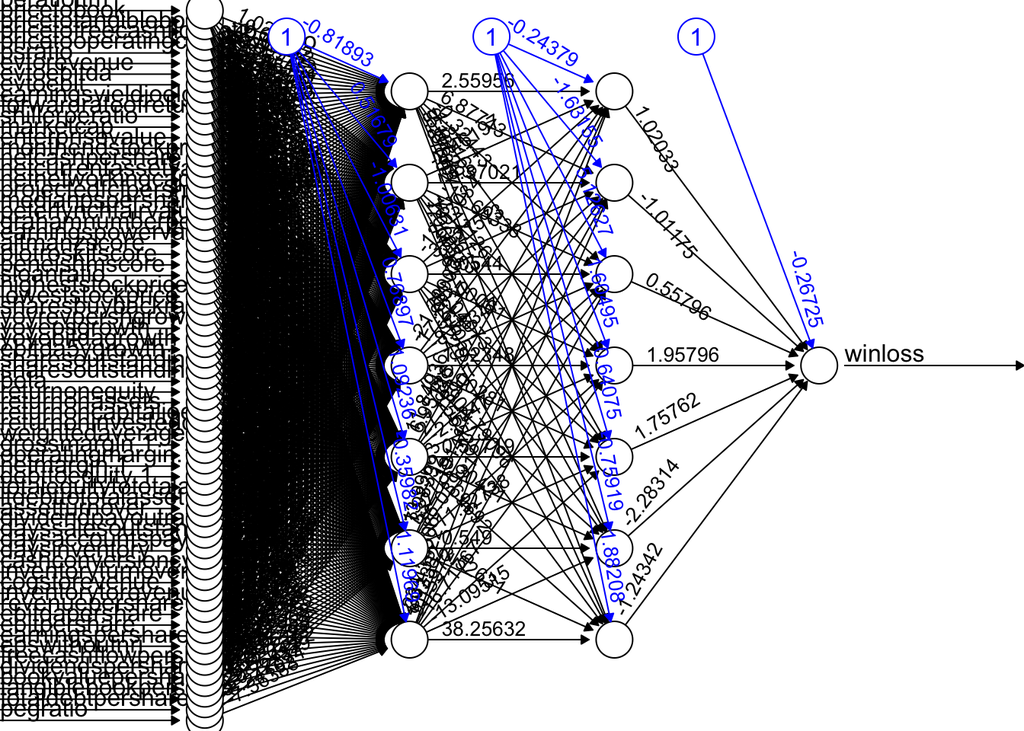

```r
plot.nn(fit,rep='best')
```

This gives the accuracy of 51.11% and precision of 47.19%. This is considerably worse than other learners.

```r
covariate_df <-testing[-69]
comp<-compute(fit,covariate_df,rep=8)
comp<-unlist(comp$net.result)
pred<-ifelse(comp>0.5,1,0)
confusionMatrix(pred,testing$winloss,positive='1')
```

```
## Confusion Matrix and Statistics
##
##           Reference
## Prediction   0   1
##          0 197 168
##          1 141 126
##
##                Accuracy : 0.5111
##                  95% CI : (0.4713, 0.5507)
##     No Information Rate : 0.5348
##     P-Value [Acc > NIR] : 0.8917
##
##                   Kappa : 0.0115
##  Mcnemar's Test P-Value : 0.1391
##
##             Sensitivity : 0.4286
##             Specificity : 0.5828
##          Pos Pred Value : 0.4719
##          Neg Pred Value : 0.5397
##              Prevalence : 0.4652
##          Detection Rate : 0.1994
##    Detection Prevalence : 0.4225
##       Balanced Accuracy : 0.5057
##
##        'Positive' Class : 1
##
```

Following this classifier will give an average return (%) of:

```r
pred<-ifelse(pred==1,'win','lose')
mean(backtest[backtest$winloss==pred & pred=='win',]$priceg)
```

```
## [1] 61.78413
```

# 5 Conclusion

- We predict if a stock ‘beats the market’ but not ‘by how much’ so the discrepancy in accuracy/precision and backtest performances between random forest and svm.
- We assume random effects among years and stocks and treat which might not necessarily hold.
- We treat the dataset as cross-sectional not panel as it naturally is.
- We exclude some data because of NAs.

One of the most noteworthy point is that according to variable importance, traditional value strategy indicators such as Joel Greenblatt’s earning yields and Piotroski’s F-score appear to be significant. Value investing does make sense in Thai market.